# Perform One-Way Anova

Aniket Roy and Krutik Shah

01/10/2020

```r
data1 <- read.csv('One-Way(Rp).csv')
data1
```

```
##    CBA CS BDA
## 1   44 55  70
## 2   54 63  75
## 3   78 58  65
## 4   46 45  50
## 5   43 76  73
## 6   50 78  85
## 7   45 48  75
## 8   76 76  65
## 9   58 53  73
## 10  70 76  80
```

## Performing One-Way Anova

One-way ANOVA (Analysis of Variance) is used to examine the differences between means of more than two independent samples. It is used when we have a categorical independent variable (treatment) (with more than two categories) and a normally distributed interval or ratio dependent variable.

H0:There is no difference between means of all three groups.

Ha:Difference among maens is significant.

## To Check Normality of data

```r
result <- shapiro.test(data1$CBA)
result
```

```
##
##  Shapiro-Wilk normality test
##
## data:  data1$CBA
## W = 0.8535, p-value = 0.06392
```

```r
result <- shapiro.test(data1$CS)
result
```

```
##
##  Shapiro-Wilk normality test
##
## data:  data1$CS
## W = 0.87468, p-value = 0.1133
```

```r
result <- shapiro.test(data1$BDA)
result
```

```
##
##  Shapiro-Wilk normality test
##
## data:  data1$BDA
## W = 0.92825, p-value = 0.4309
```

**As we can see that p-value of CBA,CS and BDA is as follows 0.06392,0.1133 and 0.4309.From this value we can say that all values are more than 0.05 so here We accept NULL Hypothesis.**

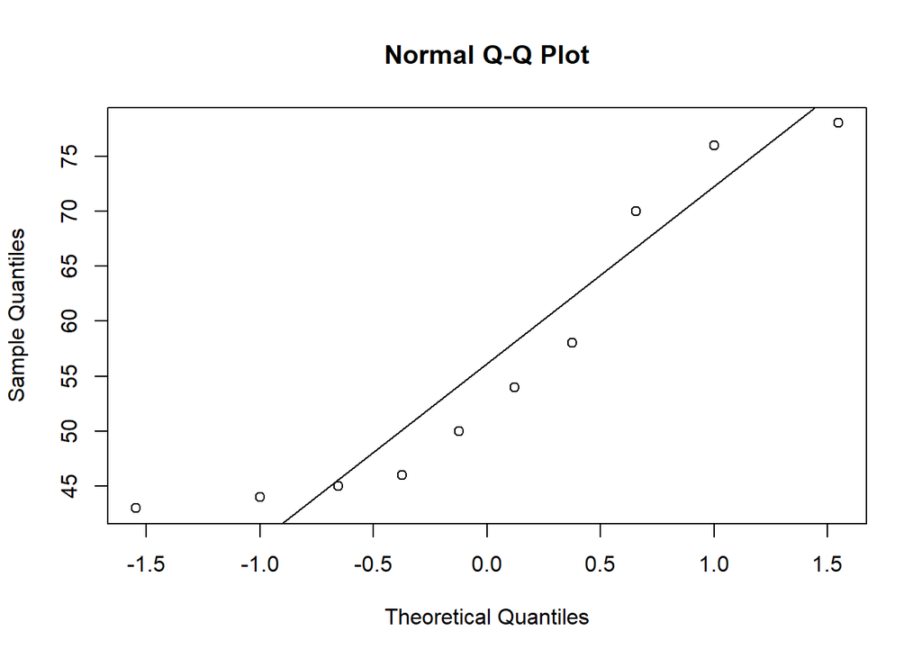

```r
qqnorm(data1$CBA)
qqline(data1$CBA, distribution=qnorm)
```

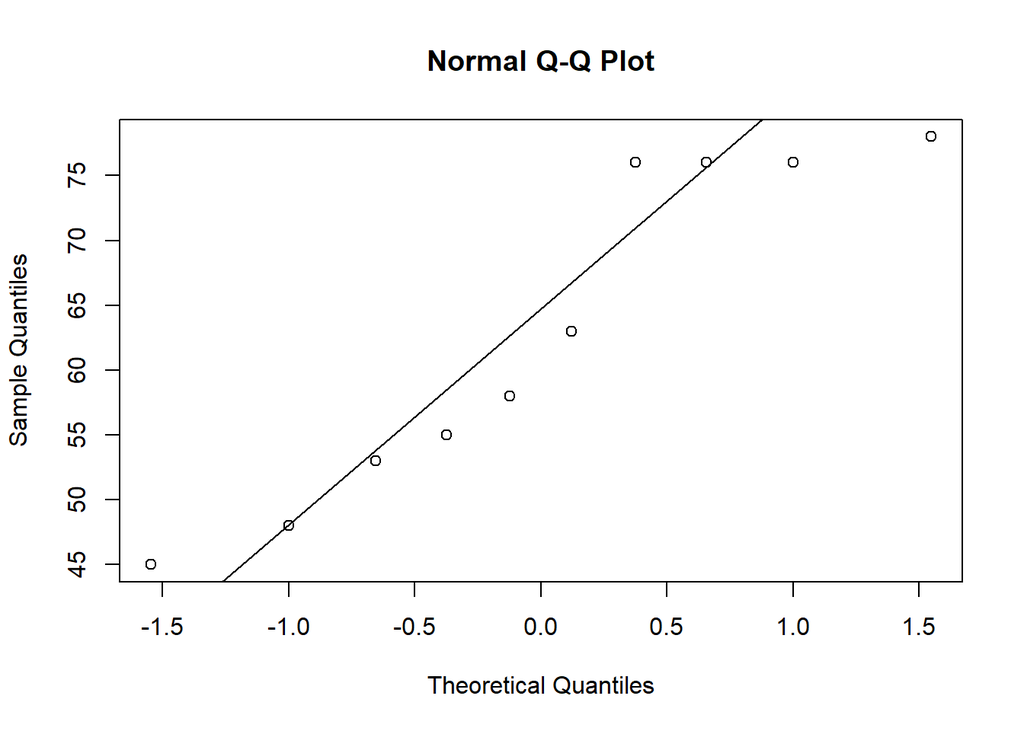

```r
qqnorm(data1$CS)
qqline(data1$CS, distribution=qnorm)
```

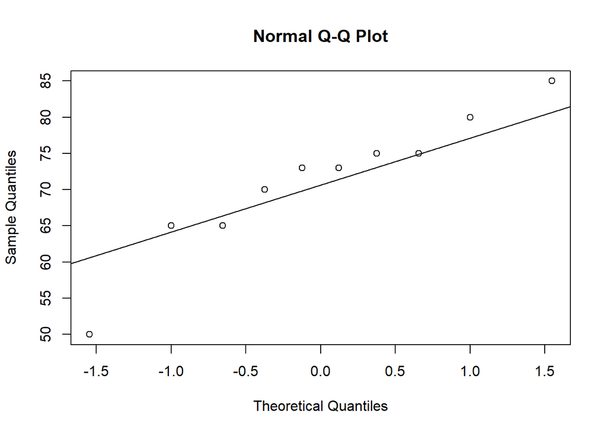

```r
qqnorm(data1$BDA)
qqline(data1$BDA, distribution=qnorm)
```

## Testing Homogeneity of Variances

**Bartlett’s test is used to test if k samples have equal variances. Equal variances across samples is called homogeneity of variances.Before applying ANOVA we have to check the assumption about the homogeneity of variances.**

```r
result <- data.frame(data1$CBA,data1$CS,data1$BDA)
res.var <- bartlett.test(list(data1$CBA,data1$CS,data1$BDA))
res.var
```

```
##
##  Bartlett test of homogeneity of variances
##
## data:  list(data1$CBA, data1$CS, data1$BDA)
## Bartlett's K-squared = 1.082, df = 2, p-value = 0.5822
```

As p value is greater than 0.05 .We fail to reject the null hypothesis H0 at 5% level of significance. We conclude that the variances are equal across samples.

Homogeneity of variance is an assumption underlying both t tests and F tests (analyses of variance, ANOVAs) in which the population variances (i.e., the distribution, or “spread,” of scores around the mean) of two or more samples are considered equal.

## One Way Anova

```r
st_result <- stack(result)
res <- oneway.test(values~ind, data = st_result)
res
```

```
##
##  One-way analysis of means (not assuming equal variances)
##
## data:  values and ind
## F = 4.0126, num df = 2.000, denom df = 17.547, p-value = 0.03673
```

## Pair-wise Comparison

```r
res.anova <- aov(values~ind, data = st_result)
summary(res.anova)
```

```
##             Df Sum Sq Mean Sq F value Pr(>F)
## ind          2   1086   543.2   3.707 0.0378 *
## Residuals   27   3957   146.6
## ---
## Signif. codes:  0 '***' 0.001 '**' 0.01 '*' 0.05 '.' 0.1 ' ' 1
```

```r
TK <- TukeyHSD(res.anova)
TK
```

```
##   Tukey multiple comparisons of means
##     95% family-wise confidence level
##
## Fit: aov(formula = values ~ ind, data = st_result)
##
## $ind
##                     diff       lwr      upr     p adj
## data1.CS-data1.CBA   6.4 -7.023333 19.82333 0.4737245
## data1.BDA-data1.CBA 14.7  1.276667 28.12333 0.0297128
## data1.BDA-data1.CS   8.3 -5.123333 21.72333 0.2917773
```

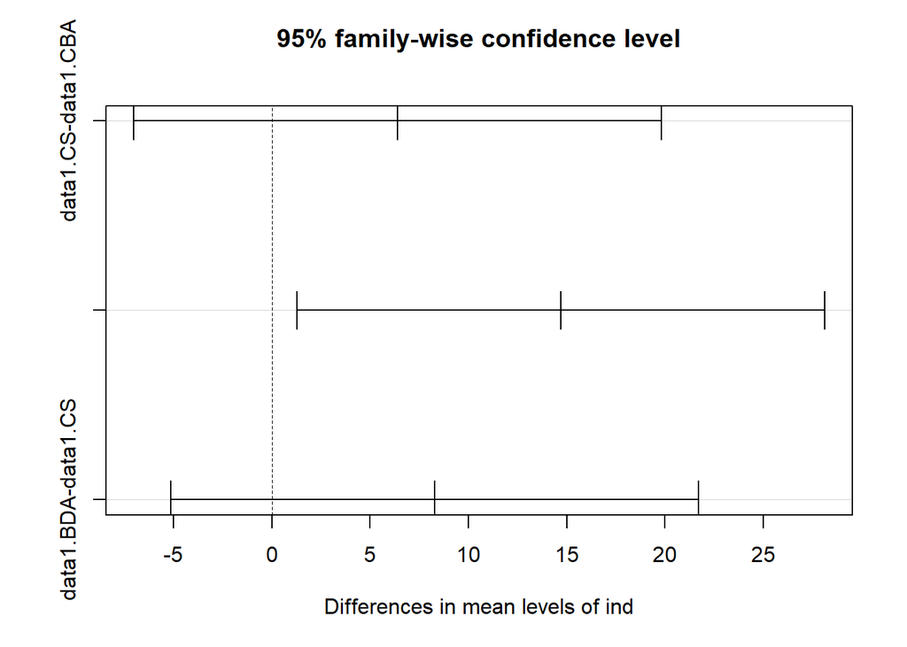

```r
plot(TK)
```

## Linear Model

```r
model1 <- lm(values ~ ind,data=st_result)
anova(model1)
```

```
## Analysis of Variance Table
##
## Response: values
##           Df Sum Sq Mean Sq F value  Pr(>F)
## ind        2 1086.5  543.23  3.7068 0.03781 *
## Residuals 27 3956.9  146.55
## ---
## Signif. codes:  0 '***' 0.001 '**' 0.01 '*' 0.05 '.' 0.1 ' ' 1
```

```r
tk1 <- TukeyHSD(aov(model1))
tk1
```

```
##   Tukey multiple comparisons of means
##     95% family-wise confidence level
##
## Fit: aov(formula = model1)
##
## $ind
##                     diff       lwr      upr     p adj
## data1.CS-data1.CBA   6.4 -7.023333 19.82333 0.4737245
## data1.BDA-data1.CBA 14.7  1.276667 28.12333 0.0297128
## data1.BDA-data1.CS   8.3 -5.123333 21.72333 0.2917773
```

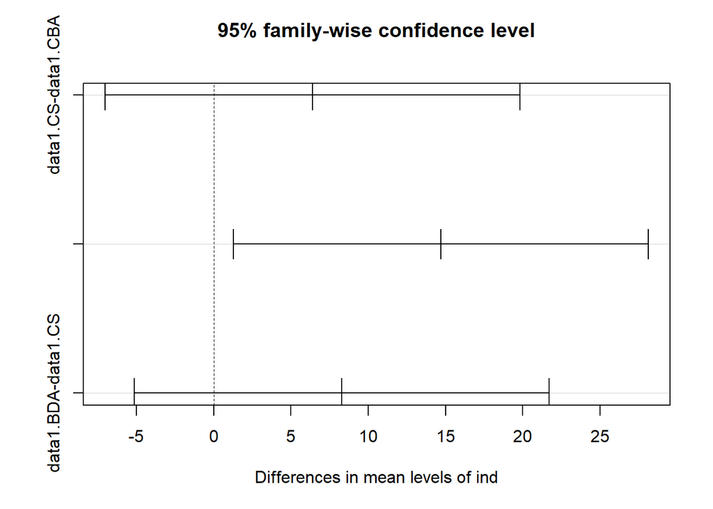

```r
plot(tk1)
```